# BIOSOPE - step 4 - Compare dada2 vs. mothur

# 1 Aim

Comparing the community composition with dada2 vs mothur

# 2 Directory structure

- **/cutadapt** : fastq files treated by cutadapt
- **/dada2** : dada2 files
- **/mothur** : mothur files

# 3 Analysis

## 3.1 To do

- Move from Species to Genus
- Color dots by division
- Do the treemaps for the two methods
- Do station histograms at genus level for chlorophyta

## 3.2 Initialize

- BIOSOPE_init.R defines all the necessary libraries and variables # r, eval=TRUE, message=FALSE, warning=FALSE

```r
source("BIOSOPE_init.R", echo = FALSE)
```

## 3.3 Read the phyloseq and database files

```r
ps_dada2 <- readRDS(file = str_c(dir_dada2, "ps_biosope_dada2.rds"))
ps_mothur <- readRDS(file = str_c(dir_mothur, "ps_biosope_mothur.rds"))
```

## 3.4 Make Simple tables from the phyloseq

Note: for Dada2 only consider the samples common to mothur and dada2merge and tranform to long format

```r
samples <- data.frame(sample_data(ps_dada2), stringsAsFactors = FALSE)

# Dada2 : only consider the samples common to mothur and dada2
otus_dada2 <- data.frame(otu_table(subset_samples(ps_dada2, mothur_missing ==
    0)))
taxa_dada2 <- data.frame(tax_table(subset_samples(ps_dada2, mothur_missing ==
    0)))

# It is necessary to create a column from the row names
otus_dada2 <- rownames_to_column(otus_dada2, var = "OTUNumber")
taxa_dada2 <- rownames_to_column(taxa_dada2, var = "OTUNumber")

# Mothur
otus_mothur <- data.frame(otu_table(ps_mothur))
taxa_mothur <- data.frame(tax_table(ps_mothur))
otus_mothur <- rownames_to_column(otus_mothur, var = "OTUNumber")
taxa_mothur <- rownames_to_column(taxa_mothur, var = "OTUNumber")
```

## 3.5 Merge and convert to long format

Note: when converting to from phyloseq format to dataframe format, an X is added at the start of column name for samples because they are starting with a digit. This X is removed.

```r
dada2_long <- left_join(taxa_dada2, otus_dada2) %>% gather(key = "sample", value = "n_seq",
    starts_with("X")) %>% mutate(sample = str_replace(sample, "X", ""))
mothur_long <- left_join(taxa_mothur, otus_mothur) %>% gather(key = "sample",
    value = "n_seq", starts_with("X")) %>% mutate(sample = str_replace(sample,
    "X", ""))
```

## 3.6 Aggregate by Division, Class, Genus, Species

```r
species_dada2 <- dada2_long %>% group_by(Division, Class, Genus, Species) %>%
    summarize(n_seq = sum(n_seq))
write_tsv(species_dada2, str_c(dir_R_out, "species_dada2.txt"), na = "")

genus_dada2 <- dada2_long %>% group_by(Division, Class, Genus) %>% summarize(n_seq = sum(n_seq))
genus_dada2 <- genus_dada2 %>% ungroup() %>% arrange(desc(n_seq))

knitr::kable(head(species_dada2, 20), caption = "Genera from dada2 - first 20 lines") %>%
    kable_styling(latex_options = "scale_down", font_size = 7)
```

| Division | Class | Genus | Species | n_seq |
| --- | --- | --- | --- | --- |
| Apicomplexa | Apicomplexa_X | Colpodella | Colpodella_pontica | 133 |
| Apusomonadidae | Apusomonadidae_Group-1 | Amastigomonas | Amastigomonas_debruynei | 660 |
| Apusomonadidae | Apusomonadidae_Group-2 | Apusomonadidae_Group-2A_XX | Apusomonadidae_Group-2A_XX_sp. | 619 |
| Apusomonadidae | Apusomonadidae_Group-2 | Apusomonadidae_Group-2B_XX | Apusomonadidae_Group-2B_XX_sp. | 8338 |
| Cercozoa | Cercozoa_X | Cercozoa_XXXX | Cercozoa_XXXX_sp. | 45 |
| Cercozoa | Endomyxa | Endo4-lineage_X | Endo4-lineage_X_sp. | 2777 |
| Cercozoa | Filosa | Discomonas | Discomonas_retusa | 3 |
| Cercozoa | Filosa-Chlorarachnea | Lotharella | Lotharella_sp. | 4 |
| Cercozoa | Filosa-Chlorarachnea | Minorisa | Minorisa_minuta | 249 |
| Cercozoa | Filosa-Chlorarachnea | Minorisa-lineage_X | Minorisa-lineage_X_sp. | 27 |
| Cercozoa | Filosa-Chlorarachnea | NPK2-lineage_X | NPK2-lineage_X_sp. | 1346 |
| Cercozoa | Filosa-Granofilosea | Massisteria | Massisteria_marina | 93 |
| Cercozoa | Filosa-Granofilosea | Massiteriidae_X | Massiteriidae_X_sp. | 383 |
| Cercozoa | Filosa-Imbricatea | Novel-clade-2_X | Novel-clade-2_X_sp. | 1728 |
| Cercozoa | Filosa-Sarcomonadea | Helkesimastix | Helkesimastix_marina | 13 |
| Cercozoa | Filosa-Thecofilosea | Botuliforma | Botuliforma_benthica | 7 |
| Cercozoa | Filosa-Thecofilosea | Protaspa | Protaspa_grandis | 183 |
| Cercozoa | Filosa-Thecofilosea | Ventrifissura | Ventrifissura_foliiformis | 5 |
| Cercozoa | Phaeodarea | Challengeron | Challengeron_tizardi | 265 |
| Cercozoa | Phaeodarea | Entocannula | Entocannula_infundibulum | 4 |

```r
species_mothur <- mothur_long %>% group_by(Division, Class, Genus, Species) %>%
    summarize(n_seq = sum(n_seq))
write_tsv(species_mothur, str_c(dir_R_out, "species_mothur.txt"), na = "")

genus_mothur <- mothur_long %>% group_by(Division, Class, Genus) %>% summarize(n_seq = sum(n_seq))
genus_mothur <- genus_mothur %>% ungroup() %>% arrange(desc(n_seq))

knitr::kable(head(genus_mothur, 20), caption = "Genera from mothur - first 20 lines") %>%
    kable_styling(latex_options = "scale_down", font_size = 7)
```

Genera from mothur - first 20 lines

| Division | Class | Genus | n_seq |
| --- | --- | --- | --- |
| Radiolaria | RAD-A | RAD-A_XXX | 11871 |
| Chlorophyta | Prasino-Clade-VII | Prasino-Clade-VII-B-1 | 8517 |
| Dinoflagellata | Syndiniales | Dino-Group-I-Clade-1_X | 7171 |
| Radiolaria | RAD-B | RAD-B-Group-I_X | 6598 |
| Chlorophyta | Mamiellophyceae | Bathycoccus | 5949 |
| Radiolaria | Acantharea | Acanthometron | 4472 |
| Apusomonadidae | Apusomonadidae_Group-2 | Apusomonadidae_Group-2B_XX | 4450 |
| Radiolaria | RAD-B | RAD-B-Group-IV_X | 4223 |
| Chlorophyta | Prasino-Clade-9 | Prasino-Clade-9-B_X | 3827 |
| Dinoflagellata | Dinophyceae | Prorocentrum | 3539 |
| Dinoflagellata | Dinophyceae | Dinophyceae_unclassified | 3356 |
| Eukaryota_unclassified | Eukaryota_unclassified | Eukaryota_unclassified | 2184 |
| Radiolaria | RAD-B | RAD-B-Group-II_X | 2116 |
| Radiolaria | Polycystinea | Spongotrochus | 2036 |
| Chlorophyta | Prasino-Clade-VII | Prasino-Clade-VII-A-4 | 2027 |
| Radiolaria | RAD-B | Sticholonche | 2000 |
| Radiolaria | Polycystinea | Spumellarida-Group-I_X | 1990 |
| Dinoflagellata | Syndiniales | Dino-Group-III_XX | 1876 |
| Cercozoa | Endomyxa | Endo4-lineage_X | 1817 |
| Radiolaria | Polycystinea | Pterocorys | 1787 |

## 3.7 Compare overall composition

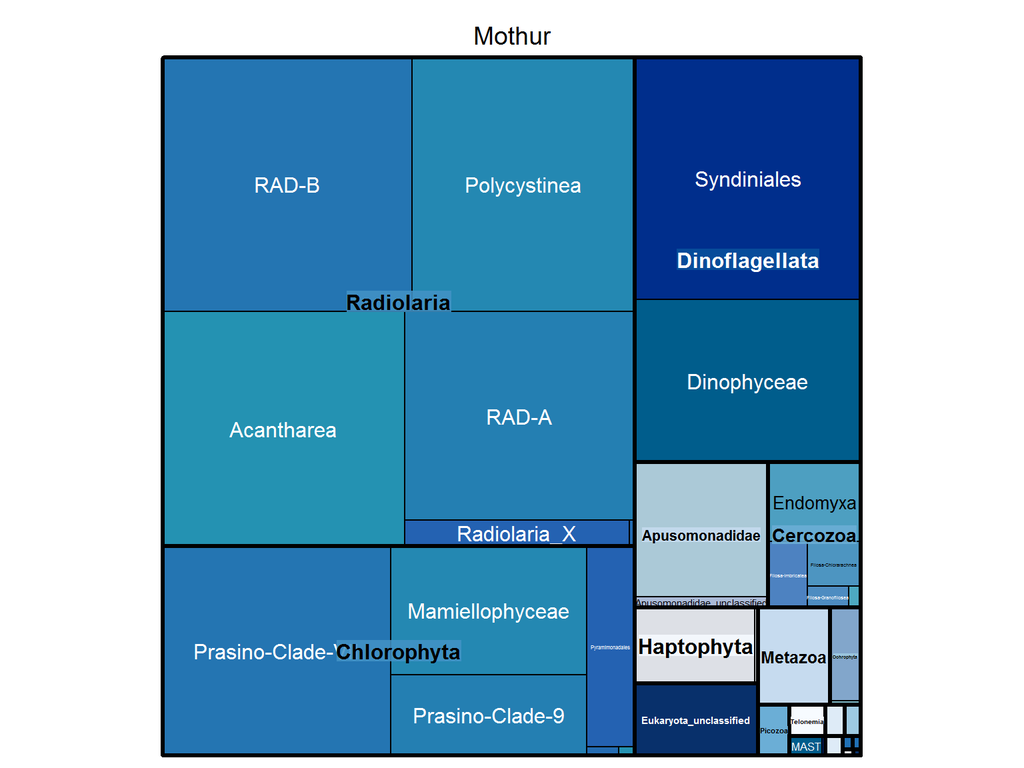

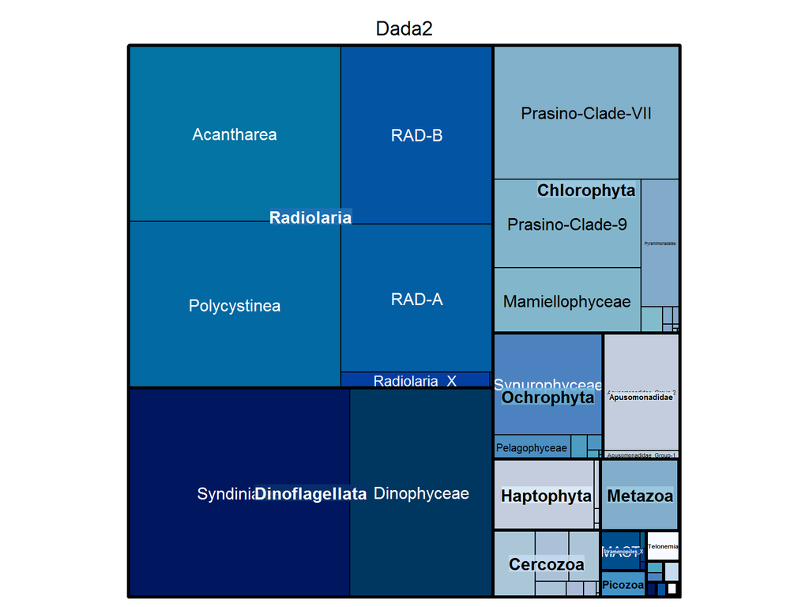

```r
dv_treemap(species_mothur, c("Division", "Class"), "n_seq", "Mothur")
dv_treemap(species_dada2, c("Division", "Class"), "n_seq", "Dada2")
```

## 3.8 Compare Chlorophyta composition

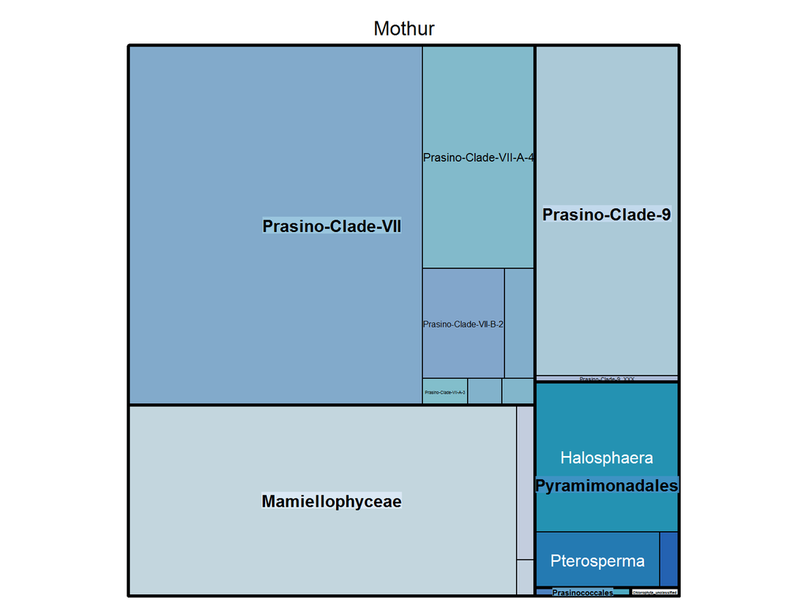

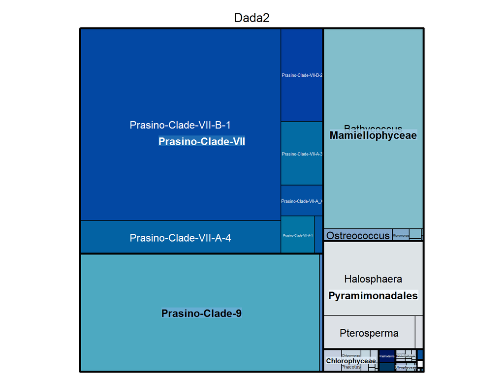

```r
dv_treemap(filter(species_mothur, Division == "Chlorophyta"), c("Class", "Genus"),
    "n_seq", "Mothur")
dv_treemap(filter(species_dada2, Division == "Chlorophyta"), c("Class", "Genus"),
    "n_seq", "Dada2")
```

## 3.9 Compare estimates of taxon abundance

### 3.9.1 Merge the two lists to compute the relation between mothur and dada2 estimates

```r
both_genus <- rbind(genus_mothur, genus_dada2) %>% group_by(Division, Class,
    Genus) %>% summarize(n_methods = n()) %>% left_join(genus_dada2) %>% dplyr::rename(dada2 = n_seq) %>%
    left_join(genus_mothur) %>% dplyr::rename(mothur = n_seq) %>% arrange(desc(mothur))
n_genus <- nrow(both_genus)
both_class <- both_genus %>% group_by(Division, Class) %>% summarise(dada2 = sum(dada2,
    na.rm = TRUE), mothur = sum(mothur, na.rm = TRUE)) %>% arrange(desc(dada2))
```

### 3.9.2 Class level

```
Call:
lm(formula = both_class$dada2 ~ both_class$mothur)

Residuals:
   Min     1Q Median     3Q    Max
-10628   -207   -167      1  13462

Coefficients:
                  Estimate Std. Error t value Pr(>|t|)
(Intercept)       199.5926   373.1680    0.53     0.59
both_class$mothur   2.3935     0.0897   26.69   <2e-16 ***
---
Signif. codes:  0 '***' 0.001 '**' 0.01 '*' 0.05 '.' 0.1 ' ' 1

Residual standard error: 2950 on 72 degrees of freedom
Multiple R-squared:  0.908, Adjusted R-squared:  0.907
F-statistic:  712 on 1 and 72 DF,  p-value: <2e-16
```

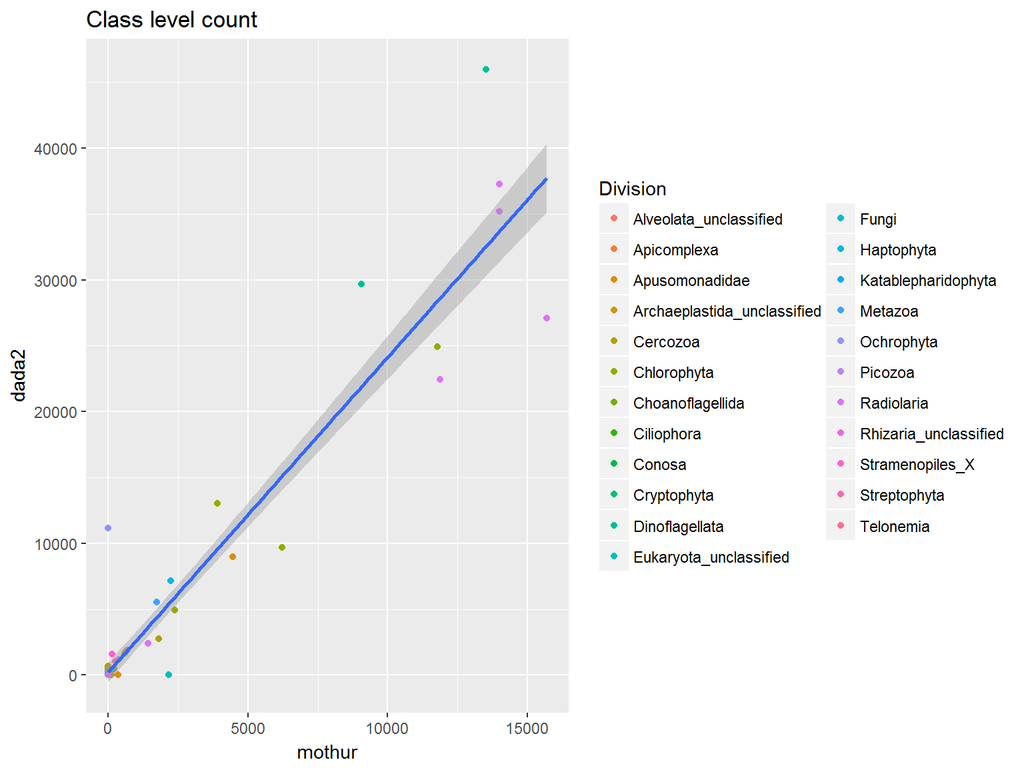

```r
ggplot(both_class) + geom_point(aes(mothur, dada2, color = Division)) + geom_smooth(aes(mothur,
    dada2), method = "lm") + ggtitle("Class level count")

summary(lm(both_class$dada2 ~ both_class$mothur))
```

### 3.9.3 Genus level

```r
ggplot(both_genus) + geom_point(aes(mothur, dada2, color = Division)) + geom_smooth(aes(mothur,
    dada2), method = "lm") + ggtitle("Genus level count")

summary(lm(both_genus$dada2 ~ both_genus$mothur))
```

[output not shown]

[figure not shown]

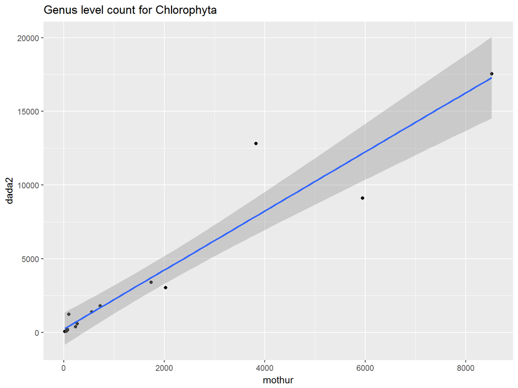

```r
# Idem for Chlorophyta

ggplot(filter(both_genus, Division == "Chlorophyta")) + geom_point(aes(mothur,
    dada2)) + geom_smooth(aes(mothur, dada2), method = "lm") + ggtitle("Genus level count for Chlorophyta")
```

### 3.9.4 Genus only found with one method

There are 9% of the genera that are only found with mothur while 57% of the genera are only found with dada2. So mothur is missing a lot of genera.

```r
genus_mothur_only <- both_genus %>% filter(is.na(dada2)) %>% arrange(desc(mothur))
n_genus_mothur_only = nrow(genus_mothur_only)

knitr::kable(head(genus_mothur_only, 30), caption = "Genera found only with mothur - top 30") %>%
    kable_styling(latex_options = "scale_down", font_size = 7)
```

Genera found only with mothur - top 30

| Division | Class | Genus | n_methods | dada2 | mothur |
| --- | --- | --- | --- | --- | --- |
| Dinoflagellata | Dinophyceae | Dinophyceae_unclassified | 1 | NA | 3356 |
| Eukaryota_unclassified | Eukaryota_unclassified | Eukaryota_unclassified | 1 | NA | 2184 |
| Metazoa | Ctenophora | Ctenophora_XX_unclassified | 1 | NA | 1463 |
| Radiolaria | Polycystinea | Spumellarida-Group-I_unclassified | 1 | NA | 1213 |
| Radiolaria | Acantharea | Acantharea_unclassified | 1 | NA | 1042 |
| Radiolaria | Acantharea | Arthracanthida-Symphyacanthida_X_unclassified | 1 | NA | 797 |
| Radiolaria | Polycystinea | Pterocoryothoidea_unclassified | 1 | NA | 617 |
| Radiolaria | Acantharea | Dorataspis | 1 | NA | 568 |
| Radiolaria | Polycystinea | Spumellarida_unclassified | 1 | NA | 559 |
| Radiolaria | Polycystinea | Nassellaria_unclassified | 1 | NA | 402 |
| Apusomonadidae | Apusomonadidae_unclassified | Apusomonadidae_unclassified | 1 | NA | 358 |
| Radiolaria | Polycystinea | Sphaerozoidae_unclassified | 1 | NA | 208 |
| Archaeplastida_unclassified | Archaeplastida_unclassified | Archaeplastida_unclassified | 1 | NA | 123 |
| Haptophyta | Prymnesiophyceae | Prymnesiophyceae_unclassified | 1 | NA | 118 |
| Radiolaria | Acantharea | Acantharea_XX_unclassified | 1 | NA | 108 |
| Dinoflagellata | Syndiniales | Dino-Group-II_unclassified | 1 | NA | 90 |
| Chlorophyta | Pyramimonadales | Pyramimonadales_XX_unclassified | 1 | NA | 86 |
| Apicomplexa | Apicomplexa_X | Colpodellidae_X_unclassified | 1 | NA | 83 |
| Radiolaria | Acantharea | Chaunacanthida_X_unclassified | 1 | NA | 83 |
| Chlorophyta | Prasino-Clade-VII | Prasino-Clade-VII-A_unclassified | 1 | NA | 75 |
| Radiolaria | RAD-B | RAD-B_X_unclassified | 1 | NA | 67 |
| Cercozoa | Cercozoa_unclassified | Cercozoa_unclassified | 1 | NA | 62 |
| Radiolaria | Acantharea | Acantharea-Group-VI_X_unclassified | 1 | NA | 50 |
| Dinoflagellata | Dinophyceae | Gymnodiniaceae_unclassified | 1 | NA | 39 |
| Radiolaria | Radiolaria_unclassified | Radiolaria_unclassified | 1 | NA | 34 |
| Chlorophyta | Chlorophyta_unclassified | Chlorophyta_unclassified | 1 | NA | 33 |
| Rhizaria_unclassified | Rhizaria_unclassified | Rhizaria_unclassified | 1 | NA | 32 |
| Radiolaria | RAD-B | RAD-B-Group-IV_unclassified | 1 | NA | 23 |
| Alveolata_unclassified | Alveolata_unclassified | Alveolata_unclassified | 1 | NA | 15 |
| Radiolaria | Polycystinea | Plagiacanthoidea_unclassified | 1 | NA | 14 |

```r
genus_dada2_only <- both_genus %>% filter(is.na(mothur)) %>% arrange(desc(dada2))
n_genus_dada2_only = nrow(genus_dada2_only)
knitr::kable(head(genus_dada2_only, 30), caption = "Genera found only with dada2 - top 30") %>%
    kable_styling(latex_options = "scale_down", font_size = 7)
```

Genera found only with dada2 - top 30

| Division | Class | Genus | n_methods | dada2 | mothur |
| --- | --- | --- | --- | --- | --- |
| Dinoflagellata | Syndiniales | Dino-Group-II-Clade-26_X | 1 | 11300 | NA |
| Ochrophyta | Synurophyceae | Tessellaria | 1 | 11146 | NA |
| Dinoflagellata | Dinophyceae | Heterocapsa | 1 | 6179 | NA |
| Radiolaria | Acantharea | Coleaspis | 1 | 1234 | NA |
| Radiolaria | Polycystinea | Spumellarida-Group-III_X | 1 | 838 | NA |
| Apusomonadidae | Apusomonadidae_Group-1 | Amastigomonas | 1 | 660 | NA |
| Dinoflagellata | Dinophyceae | Azadinium | 1 | 654 | NA |
| Radiolaria | Polycystinea | Sphaerozoum | 1 | 645 | NA |
| Apusomonadidae | Apusomonadidae_Group-2 | Apusomonadidae_Group-2A_XX | 1 | 619 | NA |
| Chlorophyta | Prasino-Clade-VII | Prasino-Clade-VII-A-1 | 1 | 580 | NA |
| Dinoflagellata | Dinophyceae | Lepidodinium | 1 | 499 | NA |
| Radiolaria | Acantharea | Acanthometra | 1 | 432 | NA |
| Radiolaria | Polycystinea | Dictyocoryne | 1 | 368 | NA |
| Ochrophyta | Chrysophyceae | Chrysophyceae_Clade-G_X | 1 | 279 | NA |
| Cercozoa | Phaeodarea | Challengeron | 1 | 265 | NA |
| Cercozoa | Filosa-Chlorarachnea | Minorisa | 1 | 249 | NA |
| Radiolaria | Polycystinea | Spongodiscus | 1 | 244 | NA |
| Stramenopiles_X | MAST | MAST-1C_X | 1 | 243 | NA |
| Radiolaria | Acantharea | Phractopelta | 1 | 240 | NA |
| Radiolaria | Polycystinea | Spongocore | 1 | 231 | NA |
| Radiolaria | Acantharea | Symphyacanthida | 1 | 204 | NA |
| Chlorophyta | Chlorophyceae | Scenedesmus | 1 | 186 | NA |
| Cercozoa | Filosa-Thecofilosea | Protaspa | 1 | 183 | NA |
| Dinoflagellata | Syndiniales | Dino-Group-II-Clade-1_X | 1 | 176 | NA |
| Choanoflagellida | Choanoflagellida_X | Choanoflagellida_XX_Clade-3_X | 1 | 169 | NA |
| Dinoflagellata | Dinophyceae | Blastodinium | 1 | 159 | NA |
| Dinoflagellata | Dinophyceae | Lessardia | 1 | 145 | NA |
| Dinoflagellata | Syndiniales | Dino-Group-II-Clade-23_X | 1 | 145 | NA |
| Radiolaria | Acantharea | Chaunacanthid | 1 | 145 | NA |
| Radiolaria | Acantharea | Staurolithium | 1 | 145 | NA |

## 3.10 Comparaison per station for the whole community

Compute sum per division and per station

```r
division_sample_dada2 <- dada2_long %>% group_by(Division, sample) %>% summarize(n_seq = sum(n_seq)) %>%
    group_by(sample) %>% mutate(n_seq_pct = n_seq/sum(n_seq))

division_sample_mothur <- mothur_long %>% group_by(Division, sample) %>% summarize(n_seq = sum(n_seq)) %>%
    group_by(sample) %>% mutate(n_seq_pct = n_seq/sum(n_seq))
```

Collapse divisions that are less than 5% of the total to “Others”

```r
# dada2

# Compute the percentage of sequences in each division and rename the
# sequences with less 1% to others
division_dada2 <- dada2_long %>% group_by(Division) %>% summarize(n_seq = sum(n_seq)) %>%
    mutate(n_seq_pct = n_seq/sum(dada2_long$n_seq) * 100) %>% mutate(Division_collapsed = if_else(n_seq_pct <
    5, "Others", Division))
# Merge the new column with 'Others'
division_sample_dada2 <- left_join(division_sample_dada2, select(division_dada2,
    Division, Division_collapsed))

# mothur

# Compute the percentage of sequences in each division and rename the
# sequences with less 1% to others
division_mothur <- mothur_long %>% group_by(Division) %>% summarize(n_seq = sum(n_seq)) %>%
    mutate(n_seq_pct = n_seq/sum(mothur_long$n_seq) * 100) %>% mutate(Division_collapsed = if_else(n_seq_pct <
    5, "Others", Division))
# Merge the new column with 'Others'
division_sample_mothur <- left_join(division_sample_mothur, select(division_mothur,
    Division, Division_collapsed))
```

Doing the graphs for the absolute abundance

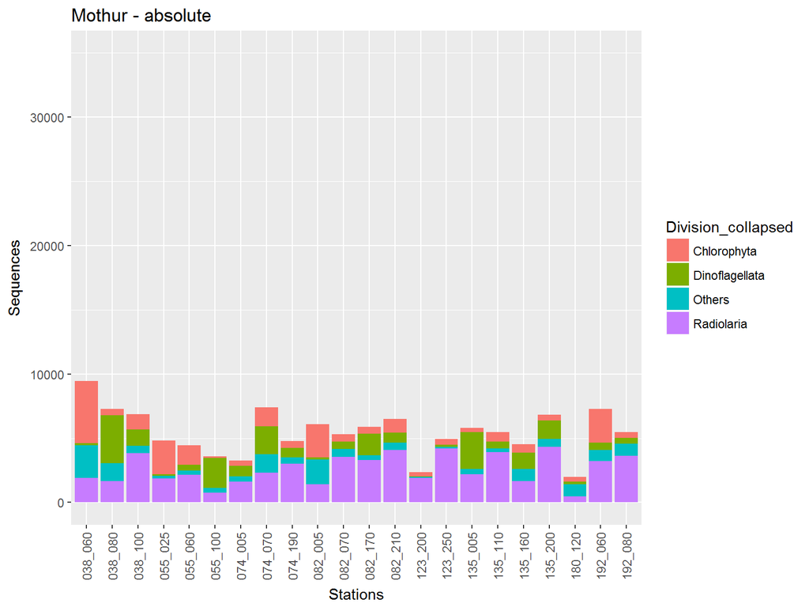

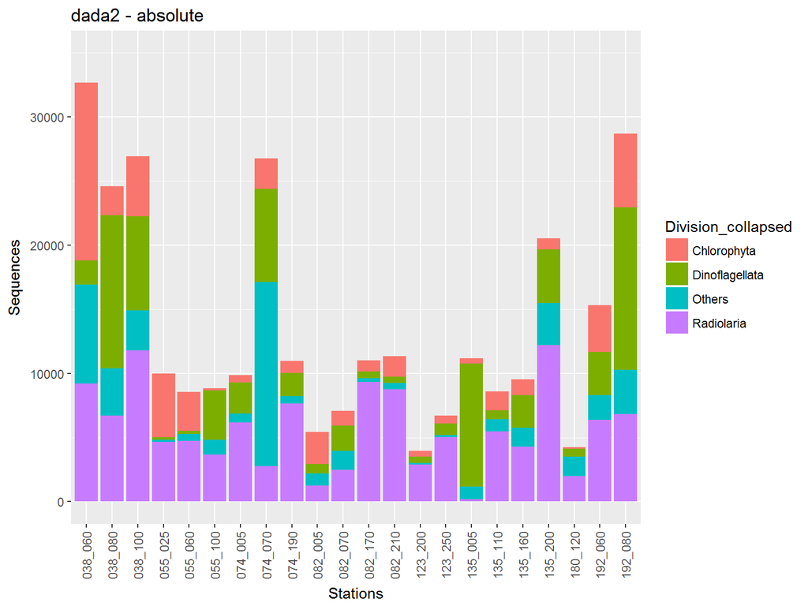

```r
ggplot(division_sample_mothur, aes(x = sample, y = n_seq, fill = Division_collapsed)) +
    geom_bar(stat = "identity") + xlab("Stations") + ylab("Sequences") + ylim(0,
    35000) + theme(axis.text.x = element_text(angle = 90, vjust = 0.5)) + ggtitle("Mothur - absolute")

ggplot(division_sample_dada2, aes(x = sample, y = n_seq, fill = Division_collapsed)) +
    geom_bar(stat = "identity") + xlab("Stations") + ylab("Sequences") + ylim(0,
    35000) + theme(axis.text.x = element_text(angle = 90, vjust = 0.5)) + ggtitle("dada2 - absolute")
```

Doing the graphs for the relative abundance

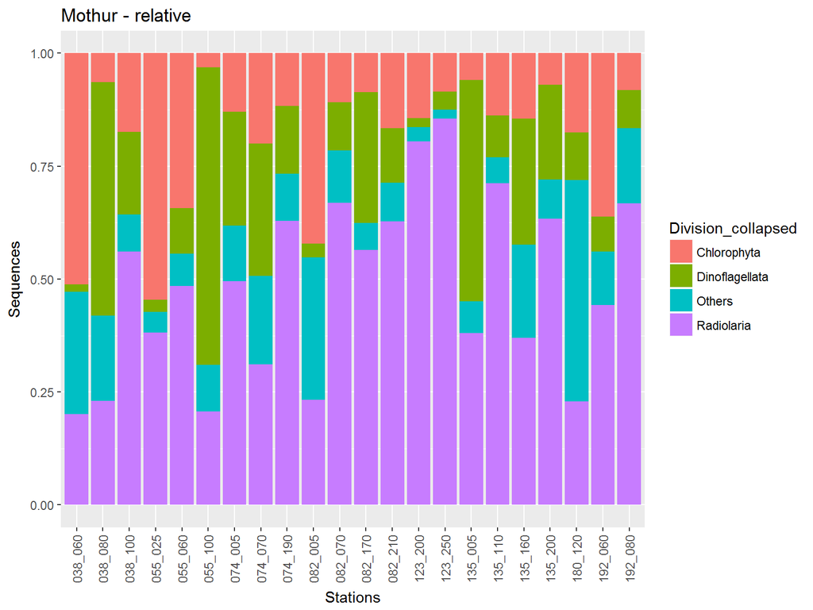

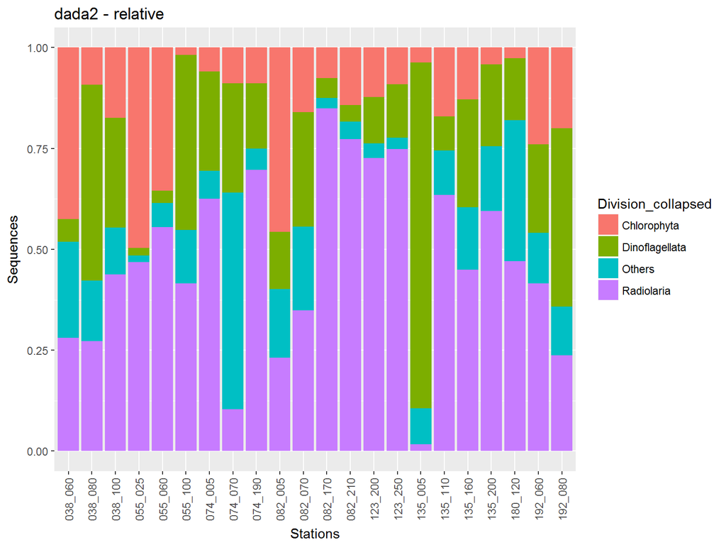

```r
ggplot(division_sample_mothur, aes(x = sample, y = n_seq_pct, fill = Division_collapsed)) +
    geom_bar(stat = "identity") + xlab("Stations") + ylab("Sequences") + theme(axis.text.x = element_text(angle = 90,
    vjust = 0.5)) + ggtitle("Mothur - relative")

ggplot(division_sample_dada2, aes(x = sample, y = n_seq_pct, fill = Division_collapsed)) +
    geom_bar(stat = "identity") + xlab("Stations") + ylab("Sequences") + theme(axis.text.x = element_text(angle = 90,
    vjust = 0.5)) + ggtitle("dada2 - relative")
```

**Notes** Some samples have different composition with dada2 than with mothur

- Sample 074_070 has a large population of Ochrophyta (collapsed into “Others” - visible by changing the threshold for others). They correspond to Chrysophyceae clade I (wrongly assigned by dada2 to Synurophyceae).
- Sample 135_005 has more Dinoflagellata than in mothur

## 3.11 Comparaison per station for Chlorophyta

Compute sum per division and per station

```r
chlo_genus_sample_dada2 <- dada2_long %>% filter(Division == "Chlorophyta") %>%
    group_by(Genus, sample) %>% summarize(n_seq = sum(n_seq)) %>% group_by(sample) %>%
    mutate(n_seq_pct = n_seq/sum(n_seq))

chlo_genus_sample_mothur <- mothur_long %>% filter(Division == "Chlorophyta") %>%
    group_by(Genus, sample) %>% summarize(n_seq = sum(n_seq)) %>% group_by(sample) %>%
    mutate(n_seq_pct = n_seq/sum(n_seq))
```

Collapse genera that are less than 1% of the total to “Others”

```r
# dada2

# Compute the percentage of sequences in each division and rename the
# sequences with less 1% to others
chlo_dada2_long <- dada2_long %>% filter(Division == "Chlorophyta")
chlo_genus_dada2 <- chlo_dada2_long %>% group_by(Genus) %>% summarize(n_seq = sum(n_seq)) %>%
    mutate(n_seq_pct = n_seq/sum(chlo_dada2_long$n_seq) * 100) %>% mutate(Genus_collapsed = if_else(n_seq_pct <
    1, "Others", Genus))
# Merge the new column with 'Others'
chlo_genus_sample_dada2 <- left_join(chlo_genus_sample_dada2, select(chlo_genus_dada2,
    Genus, Genus_collapsed))

# mothur

# Compute the percentage of sequences in each division and rename the
# sequences with less 1% to others
chlo_mothur_long <- mothur_long %>% filter(Division == "Chlorophyta")
chlo_genus_mothur <- chlo_mothur_long %>% group_by(Genus) %>% summarize(n_seq = sum(n_seq)) %>%
    mutate(n_seq_pct = n_seq/sum(chlo_mothur_long$n_seq) * 100) %>% mutate(Genus_collapsed = if_else(n_seq_pct <
    1, "Others", Genus))
# Merge the new column with 'Others'
chlo_genus_sample_mothur <- left_join(chlo_genus_sample_mothur, select(chlo_genus_mothur,
    Genus, Genus_collapsed))
```

Doing the graphs for the relative abundance

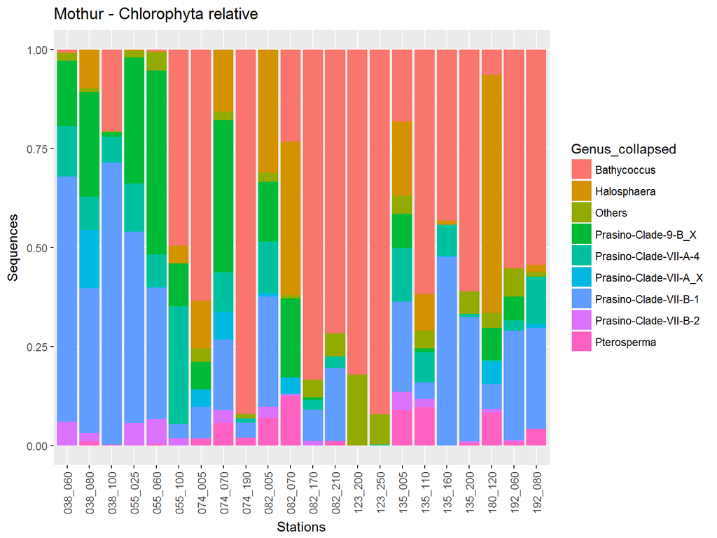

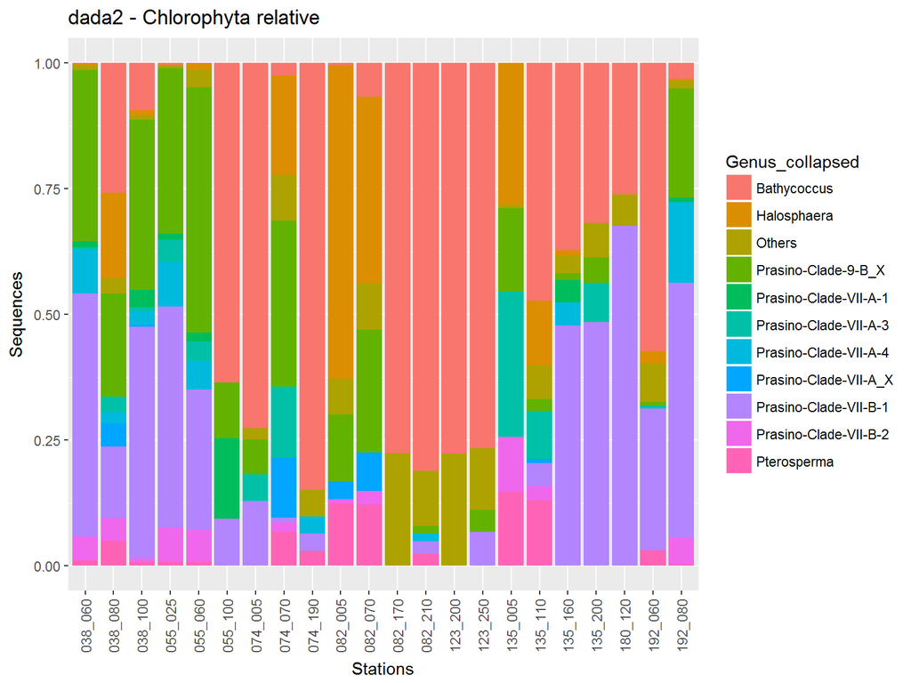

```r
ggplot(chlo_genus_sample_mothur, aes(x = sample, y = n_seq_pct, fill = Genus_collapsed)) +
    geom_bar(stat = "identity") + xlab("Stations") + ylab("Sequences") + theme(axis.text.x = element_text(angle = 90,
    vjust = 0.5)) + ggtitle("Mothur - Chlorophyta relative")

ggplot(chlo_genus_sample_dada2, aes(x = sample, y = n_seq_pct, fill = Genus_collapsed)) +
    geom_bar(stat = "identity") + xlab("Stations") + ylab("Sequences") + theme(axis.text.x = element_text(angle = 90,
    vjust = 0.5)) + ggtitle("dada2 - Chlorophyta relative")
```

# 4 Conclusions

**Mothur**

OTUs build at 98%

```
[1] "Number of sequences with mothur = 120 343"
```

```
[1] "Number of Otus with mothur      =  747"
```

```
[1] "Number of Species with mothur   =  155"
```

```
[1] "Number of Genera with mothur    =  143"
```

```
[1] "Number of genera found only with mothur =  31 (9.20 %)"
```

**Dada2**

The raw sequences have been processed with cut-adapt

```
[1] "Number of sequences with dada2 = 302 809"
```

```
[1] "Number of Otus with dada2      = 1783"
```

```
[1] "Number of Species with dada2   =  358"
```

```
[1] "Number of Genera with dada2    =  306"
```

```
[1] "Number of genera found only with dada2 = 194 (57.57 %)"
```

Daniel Vaulot

24 04 2018